# Clase 2: Introducción al modelo OLS

Econometría 1 — ECON 3311 / ECON 3321

Brayan David Flórez | Profesor complementario

2026-19

> **Universidad de los Andes** | Facultad de Economía  
> Clase complementaria — Viernes 27 de junio · 7 a 8:30 AM  
> Profesor magistral: Edicson Luna · Complementario: Brayan David Flórez

# 1 ¿Qué vimos la semana pasada?

La semana pasada aprendimos a:

- Importar bases de datos (`.dta`, `.xlsx`), explorarlas y limpiarlas.
- Crear variables nuevas con `mutate()` e `if_else()`.
- Calcular estadísticas descriptivas con `group_by()` + `summarise()`.
- Visualizar distribuciones con `ggplot2`.

Hoy damos el salto al análisis que es el corazón del curso: el **modelo de regresión lineal simple (OLS)**.

# 2 ¿Qué veremos hoy?

1. ¿Qué pregunta responde una regresión?
2. Visualizar la relación entre dos variables.
3. Estimar la regresión con `lm()`.
4. Interpretar los coeficientes en cuatro especificaciones distintas.
5. El $R^2$ y qué tan bien ajusta el modelo.

# 3 Paquetes

```r
library(pacman)
p_load(tidyverse,   # dplyr, ggplot2, etc.
       haven,       # read_dta
       broom,       # tidy(), glance()
       modelsummary # tablas de regresión
       )
```

# 4 Los datos de hoy

Usamos la base de **Finanzas territoriales municipales** de Colombia (2015–2019). Cada fila es un municipio en un año. Las variables están en **millones de pesos constantes** (excepto el PIB departamental y nacional, que están en **miles de millones** de pesos constantes de 2015).

```r
ruta_datos <- "datos"

fin <- read_dta(file.path(ruta_datos, "Finanzas_territoriales.dta"))

glimpse(fin)
```

```
#> Rows: 5,505
#> Columns: 15
#> $ AÑO                  <dbl> 2015, 2015, 2015, 2015, 2015, 2015, 2015, 2015, 2…
#> $ COD_DANE_DEPTO       <dbl> 95, 5, 25, 5, 13, 52, 25, 13, 68, 91, 91, 5, 5, 1…
#> $ DEPARTAMENTO         <chr> "TOLIMA", "ANTIOQUIA", "CUNDINAMARCA", "ANTIOQUIA…
#> $ COD_DANE_MUN         <dbl> 73226, 5789, 25599, 5044, 15580, 52022, 25899, 15…
#> $ MUNICIPIO            <chr> "CUNDAY", "TÁMESIS", "APULO", "ANZA", "QUÍPAMA", …
#> $ INGRESO_TRIBUTARIO   <dbl> 906.3032, 2789.3242, 2416.8086, 667.8024, 1093.69…
#> $ GASTO_FUNCIONAMIENTO <dbl> 1350.3691, 2609.8807, 2000.0000, 1592.2771, 1019.…
#> $ FBK                  <dbl> 3876.207, 9658.149, 7375.355, 1778.535, 7041.454,…
#> $ RESTO_INVERSION      <dbl> 7753.549, 11718.342, 6132.879, 6285.065, 5169.790…
#> $ DEFICIT_TOTAL        <dbl> -1011.9250, -5199.3186, -3887.5639, 156.7291, 946…
#> $ REGALIAS             <dbl> NA, 533.7876, 214.6508, 554.2306, 1201.5900, 263.…
#> $ TRANSFERENCIAS_SGP   <dbl> 9262.919, 6754.117, 6090.857, 6271.437, 6781.374,…
#> $ POBLACION            <dbl> 9275, 16564, 7511, 6976, 4855, 7244, 112862, 1505…
#> $ PIB_DEPTO            <dbl> 677.3681, 115446.2570, 48055.1465, 115446.2570, 2…
#> $ PIB_NACIONAL         <dbl> 804692000, 804692000, 804692000, 804692000, 80469…
```

Las variables que vamos a usar hoy:

| Variable | Descripción | Unidad |
| --- | --- | --- |
| `INGRESO_TRIBUTARIO` | Ingresos tributarios del municipio | Millones COP |
| `GASTO_FUNCIONAMIENTO` | Gasto de funcionamiento del municipio | Millones COP |
| `TRANSFERENCIAS_SGP` | Transferencias del Sistema General de Participaciones | Millones COP |
| `POBLACION` | Población total del municipio | Habitantes |
| `PIB_DEPTO` | PIB del departamento (solo varía por depto × año) | Miles de millones COP |
| `PIB_NACIONAL` | PIB nacional (varía solo por año) | Miles de millones COP |

# 5 ¿Qué pregunta responde una regresión?

La magistral ya mostró esto formalmente. Aquí la intuición:

> **Pregunta:** ¿Cómo cambia, *en promedio*, el **gasto de funcionamiento** de un municipio cuando sus **ingresos tributarios** aumentan en un millón de pesos?

Eso es exactamente lo que estima $\hat{\beta}_1$ en:

$$\text{Gasto}_i = \beta_0 + \beta_1 \cdot
\text{Ingreso}_i + \varepsilon_i$$

El truco es que **fijamos todo lo demás** (en la regresión simple, el error captura todo lo que no incluimos) y solo miramos cómo varía $Y$ con $X$.

# 6 Paso 1: ver los datos antes de regresar

Antes de estimar cualquier modelo, siempre vale la pena **ver** la relación entre las variables. Una regresión sin gráfico es como manejar con los ojos cerrados.

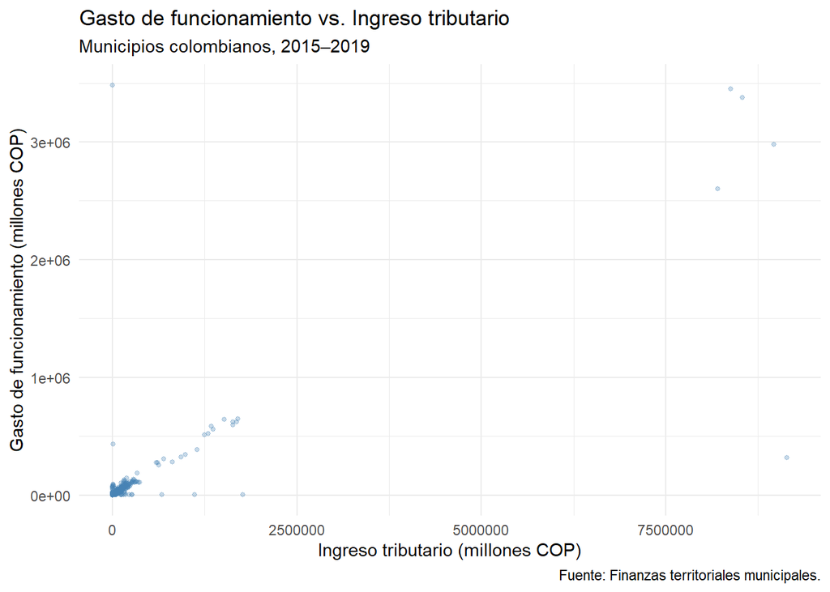

```r
fin_limpio <- fin |>
  filter(
    !is.na(INGRESO_TRIBUTARIO),
    !is.na(GASTO_FUNCIONAMIENTO),
    INGRESO_TRIBUTARIO > 0,
    GASTO_FUNCIONAMIENTO > 0
  )

ggplot(fin_limpio, aes(x = INGRESO_TRIBUTARIO, y = GASTO_FUNCIONAMIENTO)) +
  geom_point(alpha = 0.3, color = "steelblue", size = 1) +
  labs(
    title    = "Gasto de funcionamiento vs. Ingreso tributario",
    subtitle = "Municipios colombianos, 2015–2019",
    x        = "Ingreso tributario (millones COP)",
    y        = "Gasto de funcionamiento (millones COP)",
    caption  = "Fuente: Finanzas territoriales municipales."
  ) +
  theme_minimal()
```

> **¿Qué ven?** Hay una relación positiva, pero también **valores extremos (outliers)** que estiran el gráfico. Las ciudades grandes (Bogotá, Medellín, etc.) tienen ingresos y gastos muy por encima del resto. Esto es un patrón típico en datos económicos con distribuciones sesgadas. Una solución frecuente: trabajar en **logaritmos**.

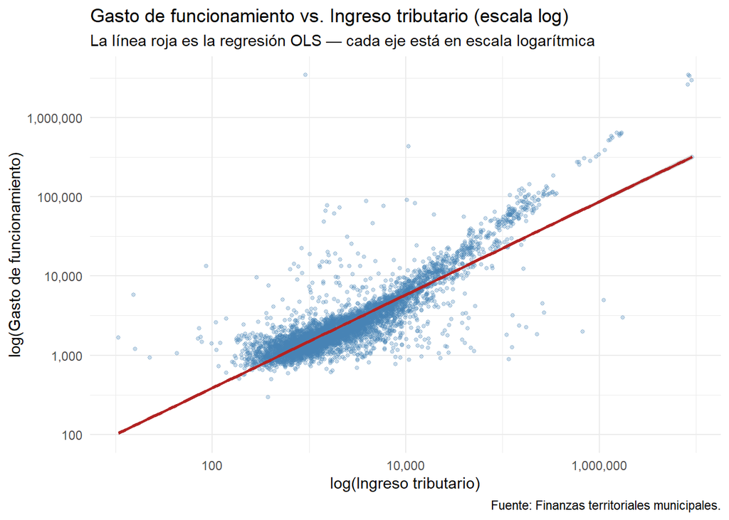

```r
ggplot(fin_limpio, aes(x = INGRESO_TRIBUTARIO, y = GASTO_FUNCIONAMIENTO)) +
  geom_point(alpha = 0.3, color = "steelblue", size = 1) +
  geom_smooth(method = "lm", color = "firebrick", se = TRUE, linewidth = 1) +
  scale_x_log10(labels = scales::comma) +
  scale_y_log10(labels = scales::comma) +
  labs(
    title    = "Gasto de funcionamiento vs. Ingreso tributario (escala log)",
    subtitle = "La línea roja es la regresión OLS — cada eje está en escala logarítmica",
    x        = "log(Ingreso tributario)",
    y        = "log(Gasto de funcionamiento)",
    caption  = "Fuente: Finanzas territoriales municipales."
  ) +
  theme_minimal()
```

# 7 Paso 2: estimar la regresión con `lm()`

La función central es `lm(y ~ x, data = ...)`. Guardamos el resultado en un objeto y lo inspeccionamos con `summary()`.

```r
# Modelo en niveles: Y = b0 + b1*X + u
m1 <- lm(GASTO_FUNCIONAMIENTO ~ INGRESO_TRIBUTARIO, data = fin_limpio)

summary(m1)
```

```
#>
#> Call:
#> lm(formula = GASTO_FUNCIONAMIENTO ~ INGRESO_TRIBUTARIO, data = fin_limpio)
#>
#> Residuals:
#>      Min       1Q   Median       3Q      Max
#> -2373358    -2345    -1966    -1240  3480401
#>
#> Coefficients:
#>                     Estimate Std. Error t value Pr(>|t|)
#> (Intercept)        3.297e+03  8.302e+02   3.972 7.22e-05 ***
#> INGRESO_TRIBUTARIO 2.937e-01  3.041e-03  96.580  < 2e-16 ***
#> ---
#> Signif. codes:  0 '***' 0.001 '**' 0.01 '*' 0.05 '.' 0.1 ' ' 1
#>
#> Residual standard error: 61370 on 5496 degrees of freedom
#> Multiple R-squared:  0.6292, Adjusted R-squared:  0.6292
#> F-statistic:  9328 on 1 and 5496 DF,  p-value: < 2.2e-16
```

La tabla tiene cuatro columnas para cada coeficiente:

| Columna | ¿Qué es? |
| --- | --- |
| `Estimate` | $\hat{\beta}$ — el coeficiente estimado |
| `Std. Error` | $\text{se}(\hat{\beta})$ — el error estándar |
| `t value` | $\hat{\beta} / \text{se}(\hat{\beta})$ — el estadístico $t$ |
| `Pr(>\|t\|)` | p-valor de la prueba $H_0: \beta = 0$ |

# 8 Paso 3: las cuatro formas funcionales

La presentación de Edicson las resume así. Lo crucial es que **el coeficiente se calcula siempre de la misma forma** (OLS), pero la interpretación cambia según las unidades de $X$ y $Y$.

## 8.1 Resumen en una tabla

| Modelo | Ecuación | Interpretación de $\hat\beta_1$ |
| --- | --- | --- |
| **nivel–nivel** | $Y = \beta_0 + \beta_1 X$ | $\Delta Y = \hat\beta_1 \cdot \Delta X$ (en unidades) |
| **log–nivel** | $\ln Y = \beta_0 + \beta_1 X$ | $\%\Delta Y \approx 100\,\hat\beta_1 \cdot \Delta X$ |
| **nivel–log** | $Y = \beta_0 + \beta_1 \ln X$ | $\Delta Y \approx (\hat\beta_1/100) \cdot \%\Delta X$ |
| **log–log** | $\ln Y = \beta_0 + \beta_1 \ln X$ | $\%\Delta Y = \hat\beta_1 \cdot \%\Delta X$ (elasticidad) |

## 8.2 Construir las variables en log

```r
fin_limpio <- fin_limpio |>
  mutate(
    log_gasto  = log(GASTO_FUNCIONAMIENTO),
    log_ing    = log(INGRESO_TRIBUTARIO)
  )
```

## 8.3 Estimación de los cuatro modelos

```r
m_nn <- lm(GASTO_FUNCIONAMIENTO ~ INGRESO_TRIBUTARIO, data = fin_limpio)  # nivel-nivel
m_ln <- lm(log_gasto             ~ INGRESO_TRIBUTARIO, data = fin_limpio)  # log-nivel
m_nl <- lm(GASTO_FUNCIONAMIENTO  ~ log_ing,            data = fin_limpio)  # nivel-log
m_ll <- lm(log_gasto             ~ log_ing,            data = fin_limpio)  # log-log
```

```r
modelsummary(
  list(
    "Nivel-Nivel" = m_nn,
    "Log-Nivel"   = m_ln,
    "Nivel-Log"   = m_nl,
    "Log-Log"     = m_ll
  ),
  stars      = TRUE,
  gof_map    = c("nobs", "r.squared"),
  coef_rename = c(
    "INGRESO_TRIBUTARIO" = "Ingreso tributario",
    "log_ing"            = "log(Ingreso tributario)"
  ),
  title = "Cuatro especificaciones del modelo: Gasto ~ Ingreso tributario"
)
```

Cuatro especificaciones del modelo: Gasto ~ Ingreso tributario

|  | Nivel-Nivel | Log-Nivel | Nivel-Log | Log-Log |
| --- | --- | --- | --- | --- |
| (Intercept) | 3297.392*** | 7.819*** | -129073.284*** | 3.248*** |
|  | (830.171) | (0.013) | (7160.934) | (0.037) |
| Ingreso tributario | 0.294*** | 0.000*** |  |  |
|  | (0.003) | (0.000) |  |  |
| log(Ingreso tributario) |  |  | 17743.064*** | 0.588*** |
|  |  |  | (900.876) | (0.005) |
| Num.Obs. | 5498 | 5498 | 5498 | 5498 |
| R2 | 0.629 | 0.108 | 0.066 | 0.743 |

+ p < 0.1, * p < 0.05, ** p < 0.01, *** p < 0.001

# 9 Paso 4: interpretar cada modelo

## 9.1 Modelo 1 — Nivel–nivel

$$\widehat{\text{Gasto}}_i = \hat\beta_0 +
\hat\beta_1 \cdot \text{Ingreso}_i$$

```r
tidy(m_nn)
```

| term | estimate | std.error | statistic | p.value |
| --- | --- | --- | --- | --- |
| (Intercept) | 3297.3921728 | 8.301711e+02 | 3.971943 | 7.220026e-05 |
| INGRESO_TRIBUTARIO | 0.2937156 | 3.041179e-03 | 96.579523 | 0.000000e+00 |

> **Interpretación:** un aumento de **1 millón de pesos** en los ingresos tributarios de un municipio está asociado, en promedio, con un aumento de $\hat\beta_1$ millones de pesos en el gasto de funcionamiento.

```r
# ¿Qué tan grande es ese efecto respecto a la media del gasto?
media_gasto <- mean(fin_limpio$GASTO_FUNCIONAMIENTO, na.rm = TRUE)

b1_nn <- coef(m_nn)["INGRESO_TRIBUTARIO"]

cat("b1 estimado:", round(b1_nn, 4), "\n")
```

```
#> b1 estimado: 0.2937
```

```r
cat("Media del gasto:", round(media_gasto, 1), "millones\n")
```

```
#> Media del gasto: 9570.4 millones
```

```r
cat("Efecto relativo a la media:", round(b1_nn / media_gasto * 100, 4), "%\n")
```

```
#> Efecto relativo a la media: 0.0031 %
```

> **¿Qué tan grande es el efecto?** el efecto representa apenas un 0.0031% de la media del gasto. No es un efecto muy grande.

**¿Tiene sentido el intercepto** $\hat\beta_0$? Aquí el intercepto es el gasto esperado cuando el ingreso tributario es **cero**, o cual no tiene mucho sentido económico (ningún municipio tiene ingreso cero). Podemos centrar la variable para que el intercepto sea interpretable:

```r
fin_limpio <- fin_limpio |>
  mutate(ing_centrado = INGRESO_TRIBUTARIO - mean(INGRESO_TRIBUTARIO, na.rm = TRUE))

m_centrado <- lm(GASTO_FUNCIONAMIENTO ~ ing_centrado, data = fin_limpio)
tidy(m_centrado)
```

| term | estimate | std.error | statistic | p.value |
| --- | --- | --- | --- | --- |
| (Intercept) | 9570.3811065 | 8.276264e+02 | 11.56365 | 1.418955e-30 |
| ing_centrado | 0.2937156 | 3.041179e-03 | 96.57952 | 0.000000e+00 |

> Ahora $\hat\beta_0$ es el gasto esperado para un municipio con el **ingreso promedio**. El coeficiente $\hat\beta_1$ **no cambia**: centrar una variable no afecta la pendiente.